# R Notebook by Aditya Meruga

In this notebook, I will be covering data from the 131 players in the 2023 Volleyball National League.

Data Dictionary

| Variable Name | Variable Type | Description |
| --- | --- | --- |
| Player | Categorical Nominal | Name of player |
| Country | Categorical Nominal | Country they are playing for |
| Age | Numerical Discrete | Age of player in years |
| Attack | Numerical Continuous | Average attack per match of player |
| Block | Numerical Continuous | Average block per match of player |
| Dig | Numerical Continuous | Average dig per match of player |
| Receive | Numerical Continuous | Average receive per match of player |
| Set | Numerical Continuous | Average set per match of player |
| Serve | Numerical Continuous | Average serve turns per match of player |
| Position | Categorical Nominal | Position of player |

Let’s start by cleaning up the data by redefining each variable!

```r
#load packages
library(dplyr)
library(stringr)
library(tidyverse)
library(psy)
library(ggplot2)
library(GGally)
library(nnet)
library(reshape2)

data(VNL2023)
#rename data
VNL <- VNL2023

# Assign variable types
VNL$Position <- as.factor(VNL$Position)
VNL$Country <- as.factor(VNL$Country)
VNL$Attack <- as.numeric(VNL$Attack)
VNL$Block <- as.numeric(VNL$Block)
VNL$Serve <- as.numeric(VNL$Serve)
VNL$Set <- as.numeric(VNL$Set)
VNL$Dig <- as.numeric(VNL$Dig)
VNL$Receive <- as.numeric(VNL$Receive)
```

Now we can inspect our data and look out for any missing values or problems that we should fix. Let’s also look at the spread of our data and check for outliers.

```r
#Inspect data
head(VNL)
```

| Player | Country | Age | Attack | Block | Serve | Set | Dig | Receive | Position |
| --- | --- | --- | --- | --- | --- | --- | --- | --- | --- |
| Ichikawa Yuki | Japan | 28 | 15.80 | 1.13 | 1.40 | 0.07 | 4.80 | 5.60 | OH |
| Romano Yuri | Italy | 26 | 12.33 | 1.07 | 1.47 | 0.00 | 3.87 | 0.00 | OP |
| Abdel-Aziz Nimir | Nederland | 31 | 15.33 | 0.67 | 2.08 | 0.00 | 3.17 | 0.25 | OP |
| Herrera Jaime Jesus | Cuba | 28 | 15.00 | 0.92 | 1.75 | 0.00 | 3.33 | 0.17 | OP |
| Takahashi Ran | Japan | 22 | 11.53 | 0.67 | 1.00 | 0.07 | 6.40 | 5.07 | OH |
| Luburic Drazen | Serbia | 30 | 14.33 | 0.58 | 1.08 | 0.00 | 4.25 | 0.00 | OP |

```r
str(VNL)
```

```
spc_tbl_ [131 × 10] (S3: spec_tbl_df/tbl_df/tbl/data.frame)
 $ Player  : chr [1:131] "Ichikawa Yuki" "Romano Yuri" "Abdel-Aziz Nimir" "Herrera Jaime Jesus" ...
 $ Country : Factor w/ 16 levels "Argentina","Brazil",..: 11 10 12 6 11 14 15 5 2 2 ...
 $ Age     : num [1:131] 28 26 31 28 22 30 35 24 29 31 ...
 $ Attack  : num [1:131] 15.8 12.3 15.3 15 11.5 ...
 $ Block   : num [1:131] 1.13 1.07 0.67 0.92 0.67 0.58 0.31 1.83 0.62 0.92 ...
 $ Serve   : num [1:131] 1.4 1.47 2.08 1.75 1 1.08 1.38 1.42 0.54 1.46 ...
 $ Set     : num [1:131] 0.07 0 0 0 0.07 0 0 0 0 0.15 ...
 $ Dig     : num [1:131] 4.8 3.87 3.17 3.33 6.4 4.25 5.85 3.42 4.15 5.38 ...
 $ Receive : num [1:131] 5.6 0 0.25 0.17 5.07 0 5 4 0 3.62 ...
 $ Position: Factor w/ 5 levels "L","MB","OH",..: 3 4 4 4 3 4 3 3 4 3 ...
 - attr(*, "spec")=
  .. cols(
  ..   Player = col_character(),
  ..   Country = col_character(),
  ..   Age = col_double(),
  ..   Attack = col_double(),
  ..   Block = col_double(),
  ..   Serve = col_double(),
  ..   Set = col_double(),
  ..   Dig = col_double(),
  ..   Receive = col_double(),
  ..   Position = col_character()
  .. )
 - attr(*, "problems")=<externalptr>
```

```r
#View summary of data
summary(VNL)
```

```
    Player               Country        Age            Attack
 Length:131         France   :10   Min.   :19.00   Min.   : 0.000
 Class :character   Poland   :10   1st Qu.:25.00   1st Qu.: 2.800
 Mode  :character   Iran     : 9   Median :27.00   Median : 5.170
                    USA      : 9   Mean   :27.81   Mean   : 5.643
                    Argentina: 8   3rd Qu.:30.00   3rd Qu.: 8.600
                    Brazil   : 8   Max.   :41.00   Max.   :15.800
                    (Other)  :77
     Block            Serve             Set              Dig
 Min.   :0.0000   Min.   :0.0000   Min.   : 0.000   Min.   : 0.530
 1st Qu.:0.3700   1st Qu.:0.2400   1st Qu.: 0.000   1st Qu.: 1.920
 Median :0.6900   Median :0.4200   Median : 0.000   Median : 3.000
 Mean   :0.8456   Mean   :0.5358   Mean   : 2.193   Mean   : 3.428
 3rd Qu.:1.1400   3rd Qu.:0.7600   3rd Qu.: 0.000   3rd Qu.: 4.510
 Max.   :4.0800   Max.   :2.0800   Max.   :26.890   Max.   :11.440

    Receive      Position
 Min.   :0.000   L :16
 1st Qu.:0.000   MB:32
 Median :0.330   OH:42
 Mean   :1.684   OP:25
 3rd Qu.:3.385   S :16
 Max.   :6.690
```

```r
#check for missing values
colSums(is.na(VNL))
```

```
  Player  Country      Age   Attack    Block    Serve      Set
       0        0        0        0        0        0        0
     Dig  Receive Position
       0        0        0
```

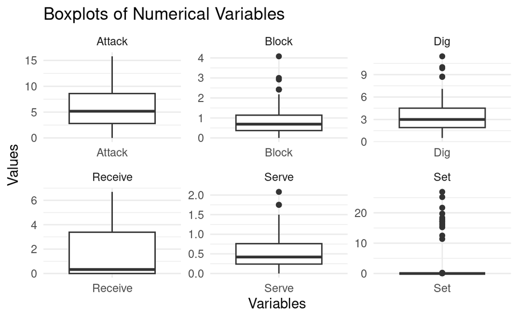

```r
#specify which variables I want to visualize using boxplots
numerical_vars <- c("Attack", "Block", "Serve", "Set", "Dig", "Receive")

#transform the dataset into long format so it is easier to create the boxplots
VNL_long <- gather(VNL, key = "variable", value = "value", all_of(numerical_vars))

#create boxplots for each of the numerical variables with different y scales for each
ggplot(VNL_long, aes(x = variable, y = value)) +
  geom_boxplot() +
  facet_wrap(~ variable, scales = "free") +
  theme_minimal() +
  labs(title = "Boxplots of Numerical Variables", x = "Variables", y = "Values")
```

Let’s create some bar graphs to compare the attack and defense stats of different positions.

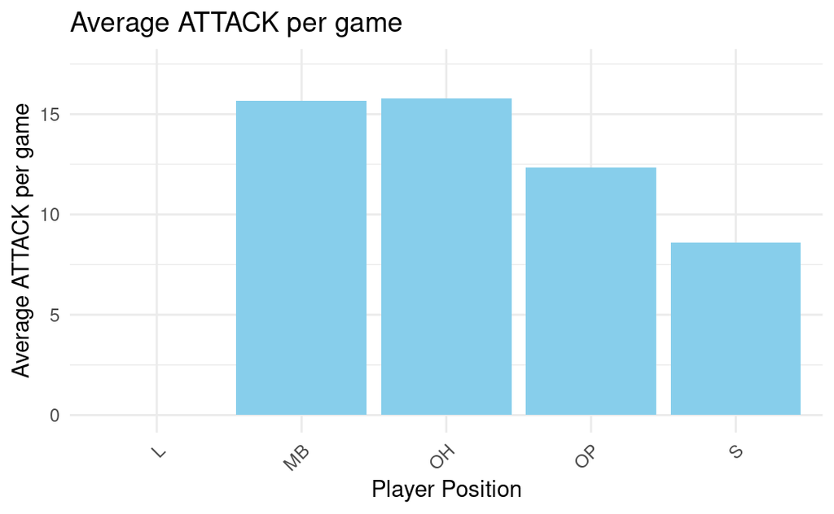

```r
# Reshape data to long format for plotting
VNL_long <- VNL %>%
  pivot_longer(cols = c(Attack, Block, Dig, Receive, Set, Serve),
               names_to = "Skill",
               values_to = "Skill_Value")
# Create bar plot for each skill
create_skill_plot <- function(skill_name) {
  # Filter data for the specific skill
  skill_data <- VNL_long %>% filter(Skill == skill_name)

  # Determine the y-axis limits based on the data
  y_limits <- c(0, max(skill_data$Skill_Value) * 1.1)
  # Adjust 1.1 factor for margin

  # Create plot
  p <- ggplot(data = skill_data, aes(x = Position, y = Skill_Value)) +
    geom_bar(stat = "identity", fill = "skyblue") +
    labs(title = paste("Average", toupper(skill_name), "per game"),  # Title for the plot
         x = "Player Position",  # X-axis label
         y = ifelse(tolower(skill_name) == "serve", "Average Serve Turns per game", paste("Average", toupper(skill_name), "per game"))) +  # Y-axis label
    scale_y_continuous(limits = y_limits) +  # Set y-axis limits
    theme_minimal() +
    theme(axis.text.x = element_text(angle = 45, hjust = 1))  # Rotate x-axis labels for better visibility

  return(p)
}

# Create plots for each skill
p_attack <- create_skill_plot("Attack")
p_block <- create_skill_plot("Block")
p_dig <- create_skill_plot("Dig")
p_receive <- create_skill_plot("Receive")
p_set <- create_skill_plot("Set")
p_serve <- create_skill_plot("Serve")

# Display the plots
print(p_attack)
```

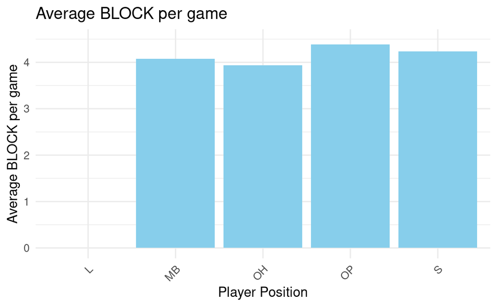

```r
print(p_block)
```

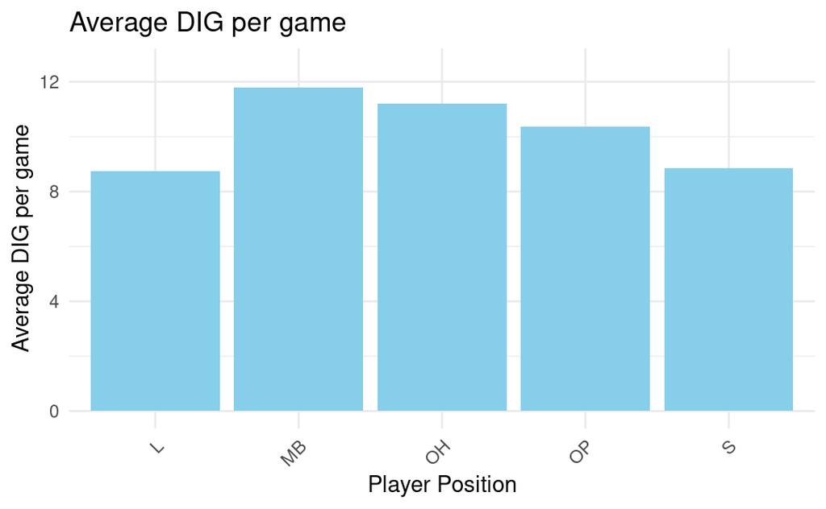

```r
print(p_dig)
```

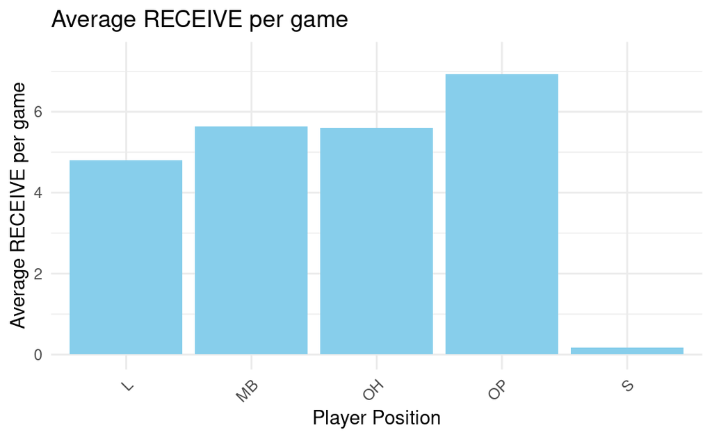

```r
print(p_receive)
```

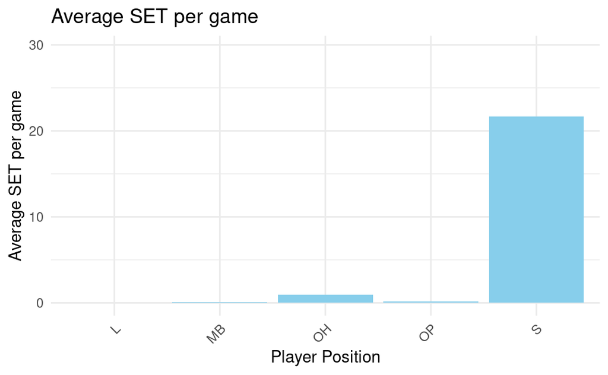

```r
print(p_set)
```